# Graded Novelty Encoding Task - original vs narrative

# The paradigm

We compare the results of the original GNET study with the contextualized one.

# Participants

## Original GNET

The online task has been started a total of 152 times.

We excluded a total of 11 runs due to irregular data leaving 141 in the analysis.

We excluded some (6) runs as they missed more than 66 of 175 trials.

We also excluded 27 runs in which the participant produced less than 0.3 corrected recognition rate for familiars in the study phase.

We also excluded 2 participants as they overused “maybe” responses in the test phase (more than 25).

We also excluded 1 run(s) as only the first run is kept in the analysis from one participant.

This left a total of 105 participants.

Maybe responses [mean(±sd)] : 12.3301887 ± 9.0970657

The sample had a mean(±sd) age of 24.5576923 ± 6.7519532.

The sample contained 88 women.

## Art narrative

The online task has been started a total of 118 times.

We excluded a total of 2 runs due to irregular data leaving 116 in the analysis.

We excluded some (1) runs as they missed more than 66 of 175 trials.

This left a total of 84 participants.

Maybe responses [mean(±sd)] : 9.9438202 ± 9.2088884

The sample had a mean(±sd) age of 19.7738095 ± 1.6232586.

The sample contained 67 women.

# Study phase:

During the study phase, the participants see familiar and novel items.

We use an ANOVA to see if there is a difference in correct rejection for the different novels.

```
## Converting to factor: stid
```

```
## Contrasts set to contr.sum for the following variables: stid
```

```
## Anova Table (Type 3 tests)
##
## Response: N
##      Effect           df  MSE         F  ges p.value
## 1      stid       1, 187 6.65 14.01 *** .038   <.001
## 2      type 3.64, 680.94 1.66 32.98 *** .077   <.001
## 3 stid:type 3.64, 680.94 1.66      1.44 .004    .223
## ---
## Signif. codes:  0 '***' 0.001 '**' 0.01 '*' 0.05 '+' 0.1 ' ' 1
##
## Sphericity correction method: GG
```

```
##  contrast                          estimate    SE  df t.ratio p.value
##  diffarr artn - sarr artn            0.7143 0.152 187   4.709  0.0002
##  diffarr artn - sarrcol artn         0.7619 0.183 187   4.166  0.0019
##  diffarr artn - sarrsha artn         1.1905 0.206 187   5.790  <.0001
##  diffarr artn - sarrshacol artn      0.7738 0.165 187   4.686  0.0002
##  diffarr artn - diffarr orig         0.4762 0.169 187   2.825  0.1358
##  diffarr artn - sarr orig            1.3143 0.200 187   6.578  <.0001
##  diffarr artn - sarrcol orig         1.3143 0.205 187   6.398  <.0001
##  diffarr artn - sarrsha orig         2.2000 0.227 187   9.695  <.0001
##  diffarr artn - sarrshacol orig      1.2952 0.194 187   6.667  <.0001
##  sarr artn - sarrcol artn            0.0476 0.187 187   0.255  1.0000
##  sarr artn - sarrsha artn            0.4762 0.183 187   2.598  0.2259
##  sarr artn - sarrshacol artn         0.0595 0.182 187   0.327  1.0000
##  sarr artn - diffarr orig           -0.2381 0.207 187  -1.151  0.9785
##  sarr artn - sarr orig               0.6000 0.233 187   2.575  0.2370
##  sarr artn - sarrcol orig            0.6000 0.238 187   2.523  0.2635
##  sarr artn - sarrsha orig            1.4857 0.257 187   5.789  <.0001
##  sarr artn - sarrshacol orig         0.5810 0.228 187   2.545  0.2521
##  sarrcol artn - sarrsha artn         0.4286 0.223 187   1.924  0.6526
##  sarrcol artn - sarrshacol artn      0.0119 0.201 187   0.059  1.0000
##  sarrcol artn - diffarr orig        -0.2857 0.214 187  -1.337  0.9436
##  sarrcol artn - sarr orig            0.5524 0.239 187   2.311  0.3871
##  sarrcol artn - sarrcol orig         0.5524 0.244 187   2.266  0.4163
##  sarrcol artn - sarrsha orig         1.4381 0.262 187   5.486  <.0001
##  sarrcol artn - sarrshacol orig      0.5333 0.234 187   2.275  0.4105
##  sarrsha artn - sarrshacol artn     -0.4167 0.205 187  -2.037  0.5744
##  sarrsha artn - diffarr orig        -0.7143 0.239 187  -2.985  0.0909
##  sarrsha artn - sarr orig            0.1238 0.262 187   0.472  1.0000
##  sarrsha artn - sarrcol orig         0.1238 0.267 187   0.464  1.0000
##  sarrsha artn - sarrsha orig         1.0095 0.283 187   3.562  0.0165
##  sarrsha artn - sarrshacol orig      0.1048 0.258 187   0.406  1.0000
##  sarrshacol artn - diffarr orig     -0.2976 0.200 187  -1.487  0.8959
##  sarrshacol artn - sarr orig         0.5405 0.227 187   2.380  0.3440
##  sarrshacol artn - sarrcol orig      0.5405 0.232 187   2.329  0.3756
##  sarrshacol artn - sarrsha orig      1.4262 0.251 187   5.675  <.0001
##  sarrshacol artn - sarrshacol orig   0.5214 0.222 187   2.346  0.3648
##  diffarr orig - sarr orig            0.8381 0.136 187   6.178  <.0001
##  diffarr orig - sarrcol orig         0.8381 0.164 187   5.123  <.0001
##  diffarr orig - sarrsha orig         1.7238 0.184 187   9.374  <.0001
##  diffarr orig - sarrshacol orig      0.8190 0.148 187   5.546  <.0001
##  sarr orig - sarrcol orig            0.0000 0.167 187   0.000  1.0000
##  sarr orig - sarrsha orig            0.8857 0.164 187   5.403  <.0001
##  sarr orig - sarrshacol orig        -0.0190 0.163 187  -0.117  1.0000
##  sarrcol orig - sarrsha orig         0.8857 0.199 187   4.446  0.0006
##  sarrcol orig - sarrshacol orig     -0.0190 0.180 187  -0.106  1.0000
##  sarrsha orig - sarrshacol orig     -0.9048 0.183 187  -4.944  0.0001
##
## P value adjustment: tukey method for comparing a family of 10 estimates
```

```
##  contrast  estimate    SE  df t.ratio p.value
##  linear      -24.89  4.33 187  -5.746  <.0001
##  quadratic     0.99  1.40 187   0.708  0.4797
##  cubic       -14.00 15.39 187  -0.910  0.3642
##  quartic      46.08  6.83 187   6.743  <.0001
##  degree 5     12.90  3.52 187   3.664  0.0003
##  degree 6      2.38  3.12 187   0.763  0.4465
```

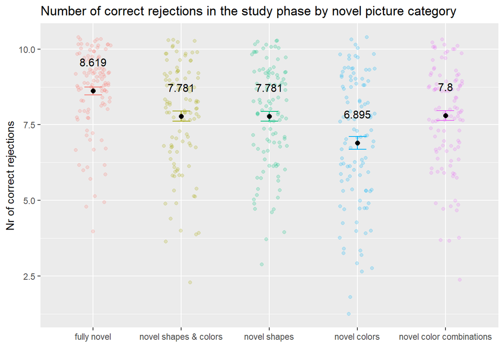

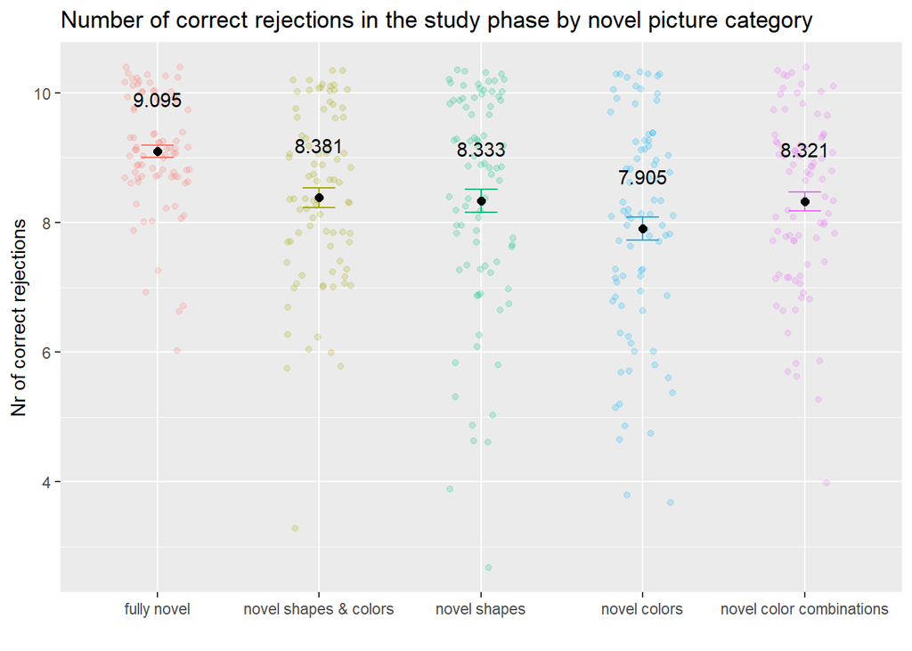

# Test phase:

This phase tests the learning that has occurred during the study phase. If the participants learned the novels in the study phase, their responses should differ for the stimuli that they have already seen during the study phase (familiars) and those that they see for the first time during the test phase (novels).

## ANOVA - Corrected Recog

```
## Converting to factor: stid
```

```
## Contrasts set to contr.sum for the following variables: stid
```

```
## Anova Table (Type 3 tests)
##
## Response: CorrRecog
##          Effect           df  MSE         F  ges p.value
## 1          stid       1, 187 4.57      0.74 .001    .390
## 2      neworder 3.85, 719.61 3.43 10.35 *** .039   <.001
## 3 stid:neworder 3.85, 719.61 3.43      1.40 .006    .234
## ---
## Signif. codes:  0 '***' 0.001 '**' 0.01 '*' 0.05 '+' 0.1 ' ' 1
##
## Sphericity correction method: GG
```

```
##  contrast        estimate    SE  df t.ratio p.value
##  A artn - B artn  -0.2500 0.245 187  -1.021  0.9907
##  A artn - C artn   0.4762 0.264 187   1.800  0.7342
##  A artn - D artn   0.1310 0.265 187   0.494  1.0000
##  A artn - E artn   0.6310 0.271 187   2.326  0.3776
##  A artn - A orig  -0.4143 0.218 187  -1.903  0.6674
##  A artn - B orig  -0.3762 0.239 187  -1.575  0.8585
##  A artn - C orig   0.0333 0.252 187   0.132  1.0000
##  A artn - D orig   0.2429 0.260 187   0.932  0.9952
##  A artn - E orig   0.9000 0.256 187   3.519  0.0189
##  B artn - C artn   0.7262 0.271 187   2.681  0.1890
##  B artn - D artn   0.3810 0.283 187   1.346  0.9414
##  B artn - E artn   0.8810 0.285 187   3.089  0.0688
##  B artn - A orig  -0.1643 0.244 187  -0.674  0.9996
##  B artn - B orig  -0.1262 0.263 187  -0.480  1.0000
##  B artn - C orig   0.2833 0.275 187   1.032  0.9899
##  B artn - D orig   0.4929 0.283 187   1.744  0.7689
##  B artn - E orig   1.1500 0.278 187   4.132  0.0022
##  C artn - D artn  -0.3452 0.300 187  -1.152  0.9783
##  C artn - E artn   0.1548 0.311 187   0.498  1.0000
##  C artn - A orig  -0.8905 0.259 187  -3.433  0.0250
##  C artn - B orig  -0.8524 0.277 187  -3.073  0.0718
##  C artn - C orig  -0.4429 0.288 187  -1.535  0.8762
##  C artn - D orig  -0.2333 0.296 187  -0.788  0.9987
##  C artn - E orig   0.4238 0.292 187   1.451  0.9090
##  D artn - E artn   0.5000 0.302 187   1.654  0.8191
##  D artn - A orig  -0.5452 0.270 187  -2.019  0.5871
##  D artn - B orig  -0.5071 0.287 187  -1.765  0.7563
##  D artn - C orig  -0.0976 0.298 187  -0.327  1.0000
##  D artn - D orig   0.1119 0.306 187   0.366  1.0000
##  D artn - E orig   0.7690 0.302 187   2.550  0.2493
##  E artn - A orig  -1.0452 0.264 187  -3.953  0.0042
##  E artn - B orig  -1.0071 0.282 187  -3.571  0.0160
##  E artn - C orig  -0.5976 0.293 187  -2.040  0.5719
##  E artn - D orig  -0.3881 0.301 187  -1.291  0.9545
##  E artn - E orig   0.2690 0.296 187   0.908  0.9961
##  A orig - B orig   0.0381 0.219 187   0.174  1.0000
##  A orig - C orig   0.4476 0.237 187   1.892  0.6744
##  A orig - D orig   0.6571 0.237 187   2.770  0.1547
##  A orig - E orig   1.3143 0.243 187   5.416  <.0001
##  B orig - C orig   0.4095 0.242 187   1.691  0.7995
##  B orig - D orig   0.6190 0.253 187   2.445  0.3056
##  B orig - E orig   1.2762 0.255 187   5.003  0.0001
##  C orig - D orig   0.2095 0.268 187   0.782  0.9988
##  C orig - E orig   0.8667 0.278 187   3.120  0.0631
##  D orig - E orig   0.6571 0.270 187   2.431  0.3137
##
## P value adjustment: tukey method for comparing a family of 10 estimates
```

```
##  contrast  estimate    SE  df t.ratio p.value
##  linear       -6.77  3.84 187  -1.765  0.0792
##  quadratic    -4.75  2.11 187  -2.253  0.0254
##  cubic       -74.66 18.38 187  -4.061  0.0001
##  quartic     -10.86 10.19 187  -1.066  0.2880
##  degree 5     13.79  5.24 187   2.630  0.0092
##  degree 6     -4.67  4.91 187  -0.952  0.3424
```

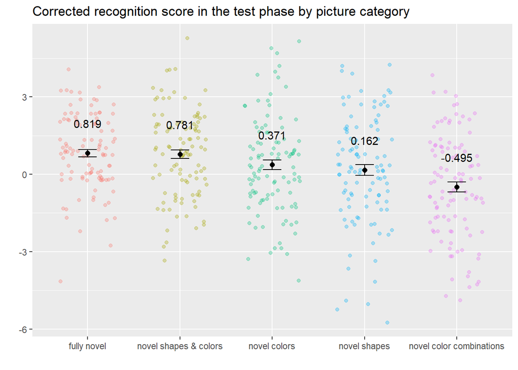

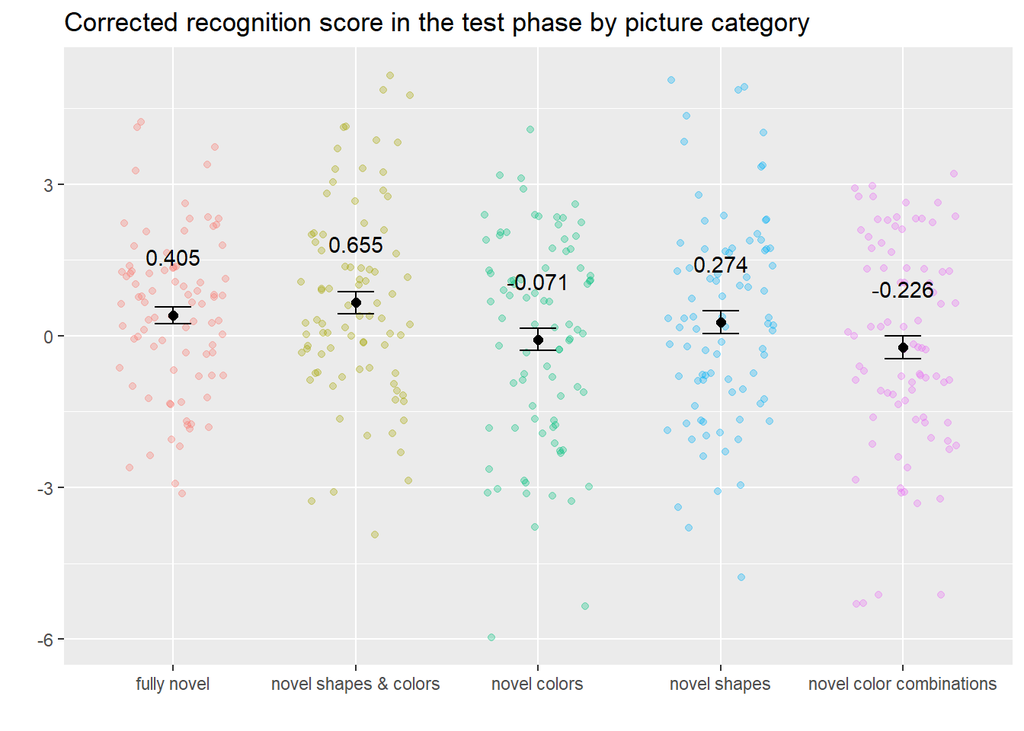

# Mixed models

The metrics

-DTF - Difference To corresponding Familiar picture All pictures are compared to a familiar. The number of differences between the three vectors of the pictures yields a difference score.

-DTAF - mean Difference To All Familiars We calculate the difference from all prototypes and take the mean for each picture in the set.

-DTN - mean Difference To all other Novels in the same category We calculate the differences between each pair of pictures and then take the mean of these differences (19 comparisons per stim).

## Study phase

With these models i tried to assess which difference index explains familiar v novel distinction in study phase the best. As far as i understand, the model with the smallest AIC fits best to our data, which means that the mean difference from the corresponding familiar worked best here. The models all show, that the more different pictures are categorized with the highest efficacy.

```
## Generalized linear mixed model fit by maximum likelihood (Laplace
##   Approximation) [glmerMod]
##  Family: binomial  ( logit )
## Formula: st_corr ~ DTF + stid + (1 | workerId)
##    Data: stlmm
##
##      AIC      BIC   logLik deviance df.resid
##  14872.6  14902.9  -7432.3  14864.6    14171
##
## Scaled residuals:
##     Min      1Q  Median      3Q     Max
## -5.0749  0.2140  0.4664  0.5953  1.2526
##
## Random effects:
##  Groups   Name        Variance Std.Dev.
##  workerId (Intercept) 0.2053   0.4531
## Number of obs: 14175, groups:  workerId, 189
##
## Fixed effects:
##             Estimate Std. Error z value Pr(>|z|)
## (Intercept)  1.02237    0.06109   16.73  < 2e-16 ***
## DTF          0.09223    0.00486   18.98  < 2e-16 ***
## stidorig    -0.30136    0.07848   -3.84 0.000123 ***
## ---
## Signif. codes:  0 '***' 0.001 '**' 0.01 '*' 0.05 '.' 0.1 ' ' 1
##
## Correlation of Fixed Effects:
##          (Intr) DTF
## DTF      -0.251
## stidorig -0.724 -0.009
```

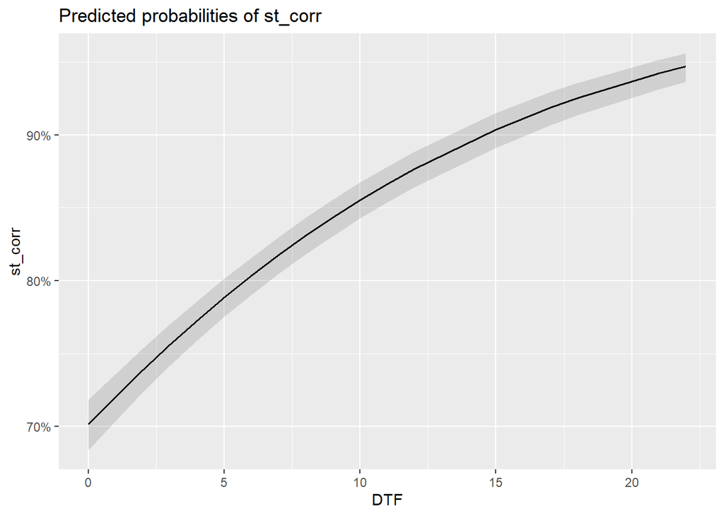

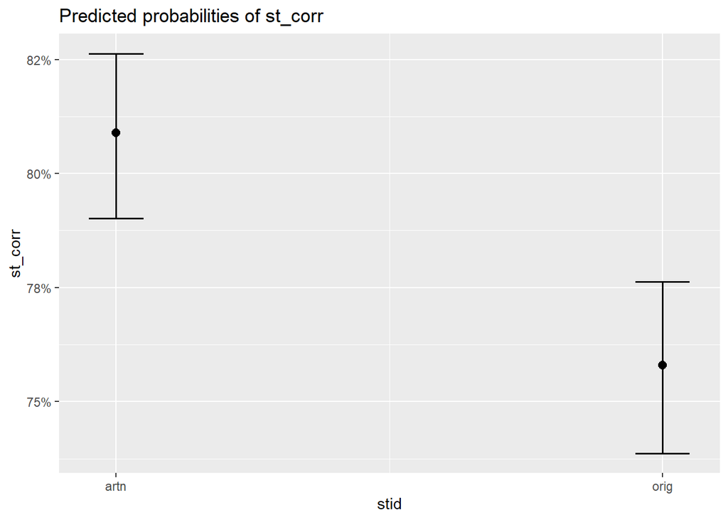

```
## Generalized linear mixed model fit by maximum likelihood (Laplace
##   Approximation) [glmerMod]
##  Family: binomial  ( logit )
## Formula: st_corr ~ DTAF + stid + (1 | workerId)
##    Data: stlmm
##
##      AIC      BIC   logLik deviance df.resid
##  14886.5  14916.7  -7439.2  14878.5    14171
##
## Scaled residuals:
##     Min      1Q  Median      3Q     Max
## -3.9958  0.2920  0.4467  0.5752  1.3498
##
## Random effects:
##  Groups   Name        Variance Std.Dev.
##  workerId (Intercept) 0.2067   0.4546
## Number of obs: 14175, groups:  workerId, 189
##
## Fixed effects:
##              Estimate Std. Error z value Pr(>|z|)
## (Intercept)  0.873198   0.063219   13.81  < 2e-16 ***
## DTAF         0.064209   0.003119   20.58  < 2e-16 ***
## stidorig    -0.302177   0.078695   -3.84 0.000123 ***
## ---
## Signif. codes:  0 '***' 0.001 '**' 0.01 '*' 0.05 '.' 0.1 ' ' 1
##
## Correlation of Fixed Effects:
##          (Intr) DTAF
## DTAF     -0.347
## stidorig -0.700 -0.012
```

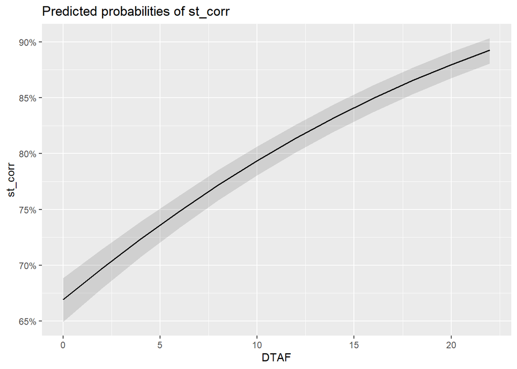

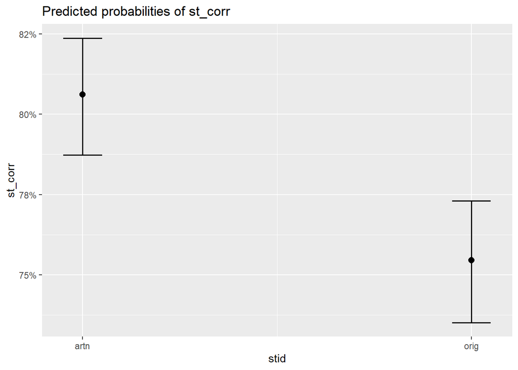

```
## Generalized linear mixed model fit by maximum likelihood (Laplace
##   Approximation) [glmerMod]
##  Family: binomial  ( logit )
## Formula: st_corr ~ DTAN + stid + (1 | workerId)
##    Data: stlmm
##
##      AIC      BIC   logLik deviance df.resid
##  14936.5  14966.7  -7464.2  14928.5    14171
##
## Scaled residuals:
##     Min      1Q  Median      3Q     Max
## -4.0663  0.3052  0.4517  0.5757  1.3351
##
## Random effects:
##  Groups   Name        Variance Std.Dev.
##  workerId (Intercept) 0.2049   0.4527
## Number of obs: 14175, groups:  workerId, 189
##
## Fixed effects:
##              Estimate Std. Error z value Pr(>|z|)
## (Intercept)  0.887668   0.063306   14.02  < 2e-16 ***
## DTAN         0.062162   0.003181   19.54  < 2e-16 ***
## stidorig    -0.301127   0.078428   -3.84 0.000123 ***
## ---
## Signif. codes:  0 '***' 0.001 '**' 0.01 '*' 0.05 '.' 0.1 ' ' 1
##
## Correlation of Fixed Effects:
##          (Intr) DTAN
## DTAN     -0.358
## stidorig -0.697 -0.011
```

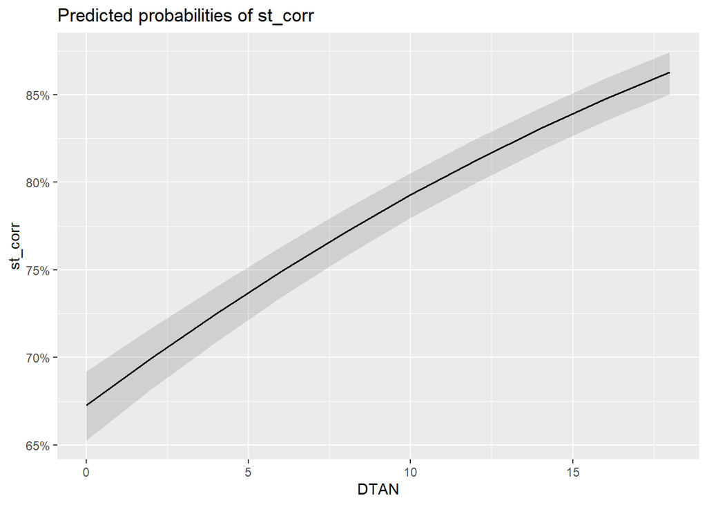

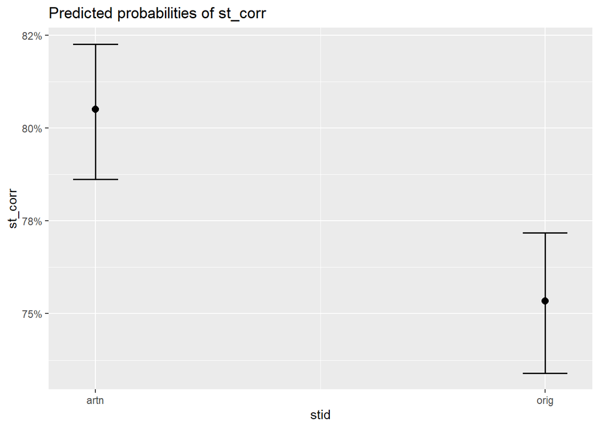

|  | st_corr |  |  |  | st_corr |  |  |  | st_corr |  |  |  |
| --- | --- | --- | --- | --- | --- | --- | --- | --- | --- | --- | --- | --- |
| Predictors | Log-Odds | std. Error | CI | p | Log-Odds | std. Error | CI | p | Log-Odds | std. Error | CI | p |
| (Intercept) | 1.02 | 0.06 | 0.90 – 1.14 | **<0.001** | 0.87 | 0.06 | 0.75 – 1.00 | **<0.001** | 0.89 | 0.06 | 0.76 – 1.01 | **<0.001** |
| DTF | 0.09 | 0.00 | 0.08 – 0.10 | **<0.001** |  |  |  |  |  |  |  |  |
| stid [orig] | -0.30 | 0.08 | -0.46 – -0.15 | **<0.001** | -0.30 | 0.08 | -0.46 – -0.15 | **<0.001** | -0.30 | 0.08 | -0.45 – -0.15 | **<0.001** |
| DTAF |  |  |  |  | 0.06 | 0.00 | 0.06 – 0.07 | **<0.001** |  |  |  |  |
| DTAN |  |  |  |  |  |  |  |  | 0.06 | 0.00 | 0.06 – 0.07 | **<0.001** |
| Random Effects |  |  |  |  |  |  |  |  |  |  |  |  |
| σ<sup>2</sup> | 3.29 |  |  |  | 3.29 |  |  |  | 3.29 |  |  |  |
| τ<sub>00</sub> | 0.21 <sub>workerId</sub> |  |  |  | 0.21 <sub>workerId</sub> |  |  |  | 0.20 <sub>workerId</sub> |  |  |  |
| ICC | 0.06 |  |  |  | 0.06 |  |  |  | 0.06 |  |  |  |
| N | 189 <sub>workerId</sub> |  |  |  | 189 <sub>workerId</sub> |  |  |  | 189 <sub>workerId</sub> |  |  |  |
| Observations | 14175 |  |  |  | 14175 |  |  |  | 14175 |  |  |  |
| Marginal R<sup>2</sup> / Conditional R<sup>2</sup> | 0.073 / 0.128 |  |  |  | 0.054 / 0.110 |  |  |  | 0.047 / 0.103 |  |  |  |
| AIC | 14872.619 |  |  |  | 14886.489 |  |  |  | 14936.486 |  |  |  |
| AICc | 14872.621 |  |  |  | 14886.492 |  |  |  | 14936.489 |  |  |  |

## Test phase

### Models #1 - without random slope term

Logistic mixed regression for the test phase. Does difference from prototypes or familiarity/novelty have an effect on correct categorization in the test phase?

```
## Generalized linear mixed model fit by maximum likelihood (Laplace
##   Approximation) [glmerMod]
##  Family: binomial  ( logit )
## Formula: rt_resp ~ DTF * tq + stid + (1 | workerId)
##    Data: tdlmm
##
##      AIC      BIC   logLik deviance df.resid
##  19231.5  19277.4  -9609.8  19219.5    15470
##
## Scaled residuals:
##     Min      1Q  Median      3Q     Max
## -2.1769 -0.7855 -0.4862  0.9661  5.2913
##
## Random effects:
##  Groups   Name        Variance Std.Dev.
##  workerId (Intercept) 0.345    0.5874
## Number of obs: 15476, groups:  workerId, 189
##
## Fixed effects:
##              Estimate Std. Error z value Pr(>|z|)
## (Intercept)  0.367361   0.079601   4.615 3.93e-06 ***
## DTF         -0.121464   0.005789 -20.981  < 2e-16 ***
## tqold       -0.201173   0.058583  -3.434 0.000595 ***
## stidorig    -0.163273   0.093096  -1.754 0.079464 .
## DTF:tqold    0.045052   0.007607   5.922 3.18e-09 ***
## ---
## Signif. codes:  0 '***' 0.001 '**' 0.01 '*' 0.05 '.' 0.1 ' ' 1
##
## Correlation of Fixed Effects:
##           (Intr) DTF    tqold  stidrg
## DTF       -0.442
## tqold     -0.402  0.599
## stidorig  -0.644  0.001  0.001
## DTF:tqold  0.336 -0.758 -0.802 -0.001
```

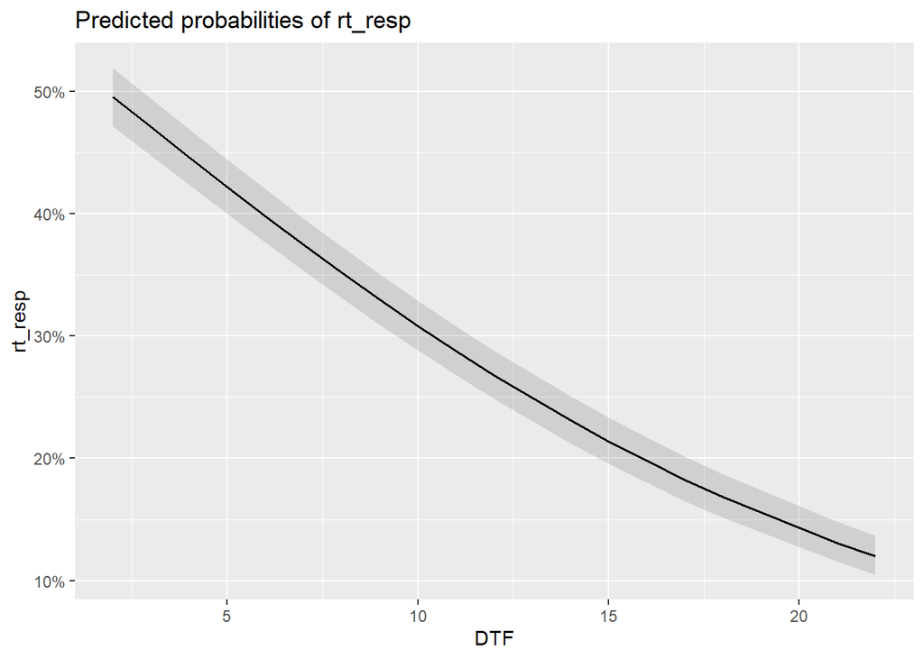

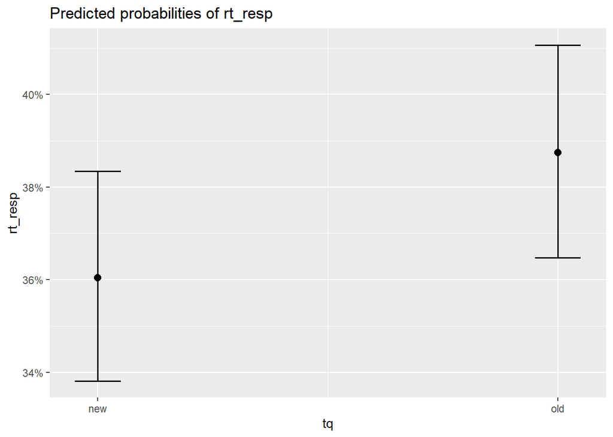

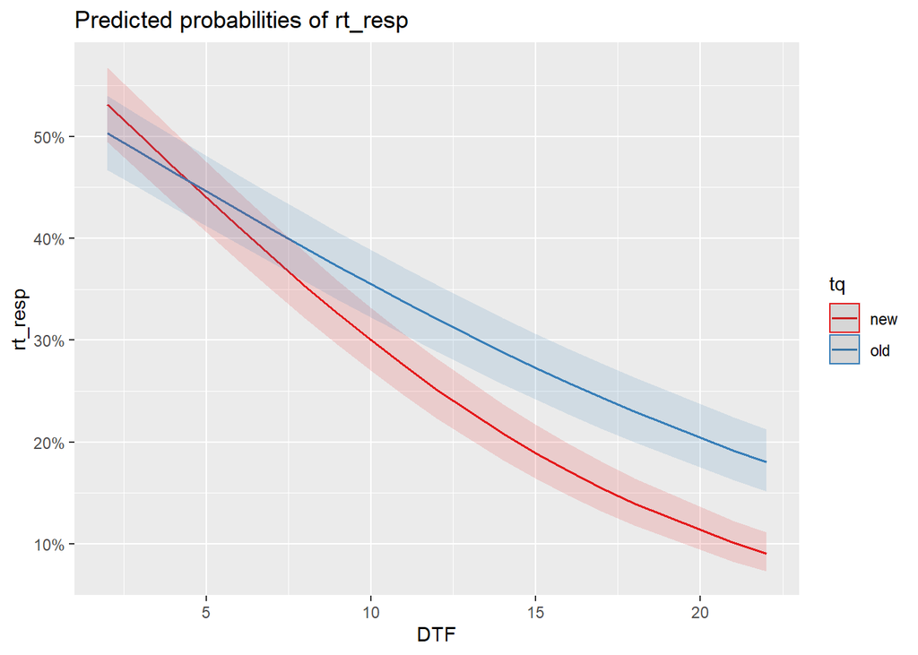

```
## Generalized linear mixed model fit by maximum likelihood (Laplace
##   Approximation) [glmerMod]
##  Family: binomial  ( logit )
## Formula: rt_resp ~ DTAF * tq + stid + (1 | workerId)
##    Data: tdlmm
##
##      AIC      BIC   logLik deviance df.resid
##  19256.0  19301.9  -9622.0  19244.0    15470
##
## Scaled residuals:
##     Min      1Q  Median      3Q     Max
## -2.1080 -0.7879 -0.4882  0.9654  4.3013
##
## Random effects:
##  Groups   Name        Variance Std.Dev.
##  workerId (Intercept) 0.3423   0.5851
## Number of obs: 15476, groups:  workerId, 189
##
## Fixed effects:
##              Estimate Std. Error z value Pr(>|z|)
## (Intercept)  2.188694   0.144351  15.162  < 2e-16 ***
## DTAF        -0.204536   0.009992 -20.469  < 2e-16 ***
## tqold       -0.644880   0.173569  -3.715 0.000203 ***
## stidorig    -0.165332   0.092772  -1.782 0.074726 .
## DTAF:tqold   0.057473   0.013500   4.257 2.07e-05 ***
## ---
## Signif. codes:  0 '***' 0.001 '**' 0.01 '*' 0.05 '.' 0.1 ' ' 1
##
## Correlation of Fixed Effects:
##            (Intr) DTAF   tqold  stidrg
## DTAF       -0.870
## tqold      -0.653  0.721
## stidorig   -0.356  0.003  0.002
## DTAF:tqold  0.642 -0.737 -0.979 -0.002
```

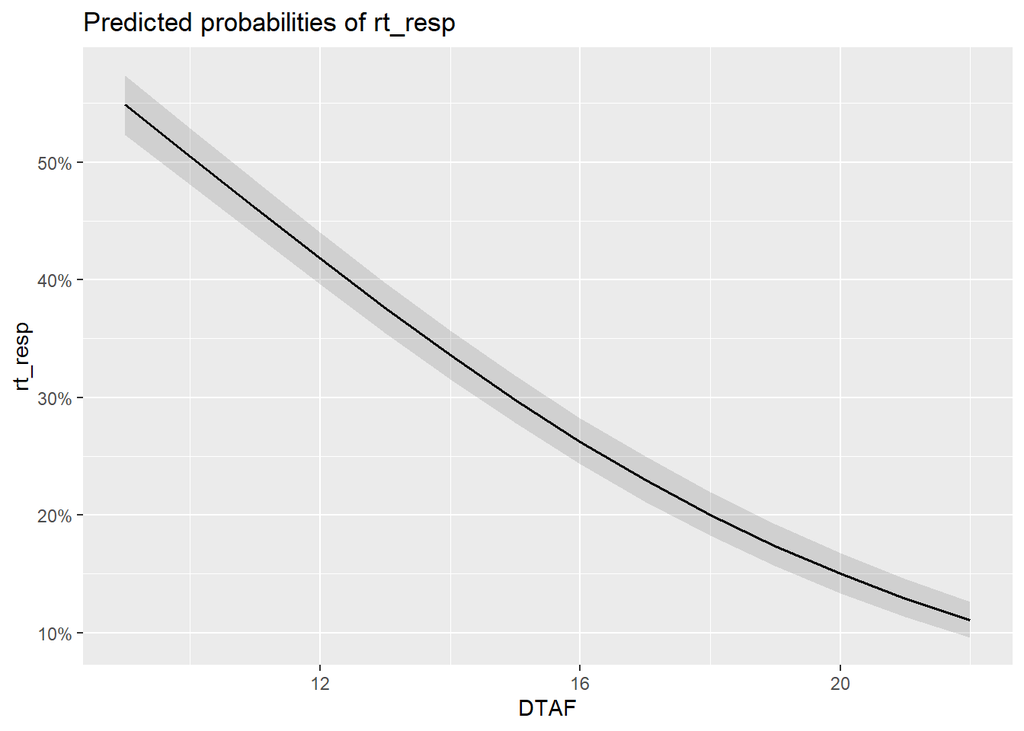

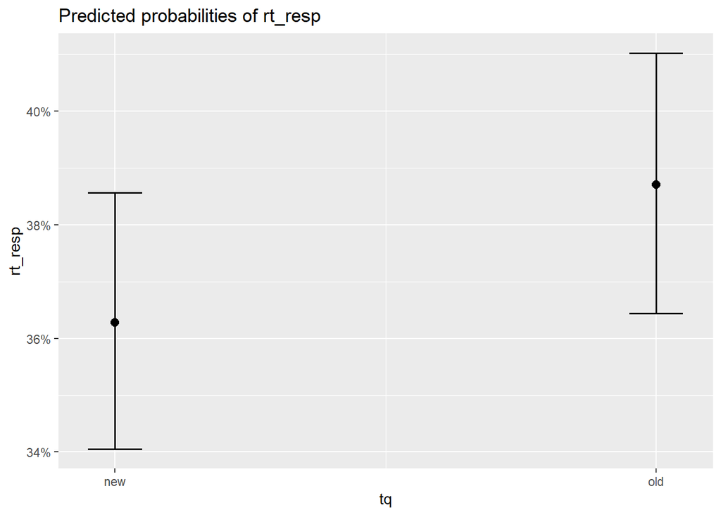

```
## Data were 'prettified'. Consider using `terms="DTAF [all]"` to get smooth plots.
```

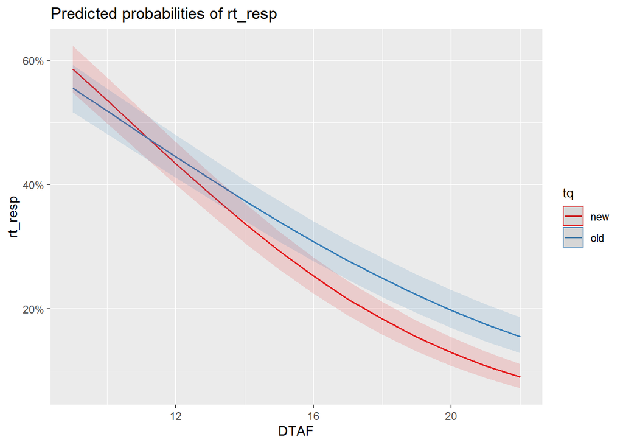

```
## Generalized linear mixed model fit by maximum likelihood (Laplace
##   Approximation) [glmerMod]
##  Family: binomial  ( logit )
## Formula: rt_resp ~ DTAN * tq + stid + (1 | workerId)
##    Data: tdlmm
##
##      AIC      BIC   logLik deviance df.resid
##  19379.5  19425.3  -9683.7  19367.5    15470
##
## Scaled residuals:
##     Min      1Q  Median      3Q     Max
## -2.2230 -0.7782 -0.5149  0.9741  4.8069
##
## Random effects:
##  Groups   Name        Variance Std.Dev.
##  workerId (Intercept) 0.3394   0.5826
## Number of obs: 15476, groups:  workerId, 189
##
## Fixed effects:
##             Estimate Std. Error z value Pr(>|z|)
## (Intercept)  3.04606    0.19210  15.856  < 2e-16 ***
## DTAN        -0.27374    0.01416 -19.331  < 2e-16 ***
## tqold       -0.75193    0.24831  -3.028 0.002460 **
## stidorig    -0.16760    0.09239  -1.814 0.069668 .
## DTAN:tqold   0.06754    0.01945   3.472 0.000516 ***
## ---
## Signif. codes:  0 '***' 0.001 '**' 0.01 '*' 0.05 '.' 0.1 ' ' 1
##
## Correlation of Fixed Effects:
##            (Intr) DTAN   tqold  stidrg
## DTAN       -0.929
## tqold      -0.679  0.716
## stidorig   -0.268  0.004  0.003
## DTAN:tqold  0.674 -0.725 -0.990 -0.003
## optimizer (Nelder_Mead) convergence code: 0 (OK)
## Model failed to converge with max|grad| = 0.0035525 (tol = 0.002, component 1)
```

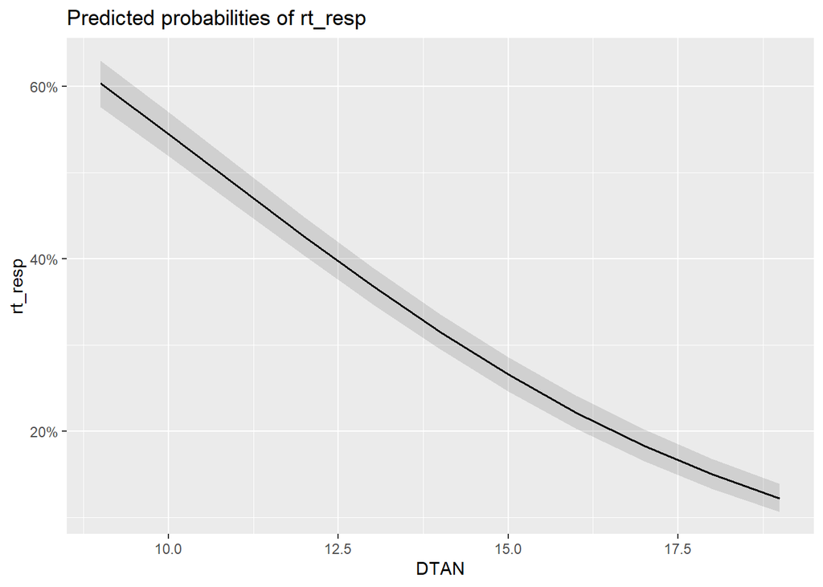

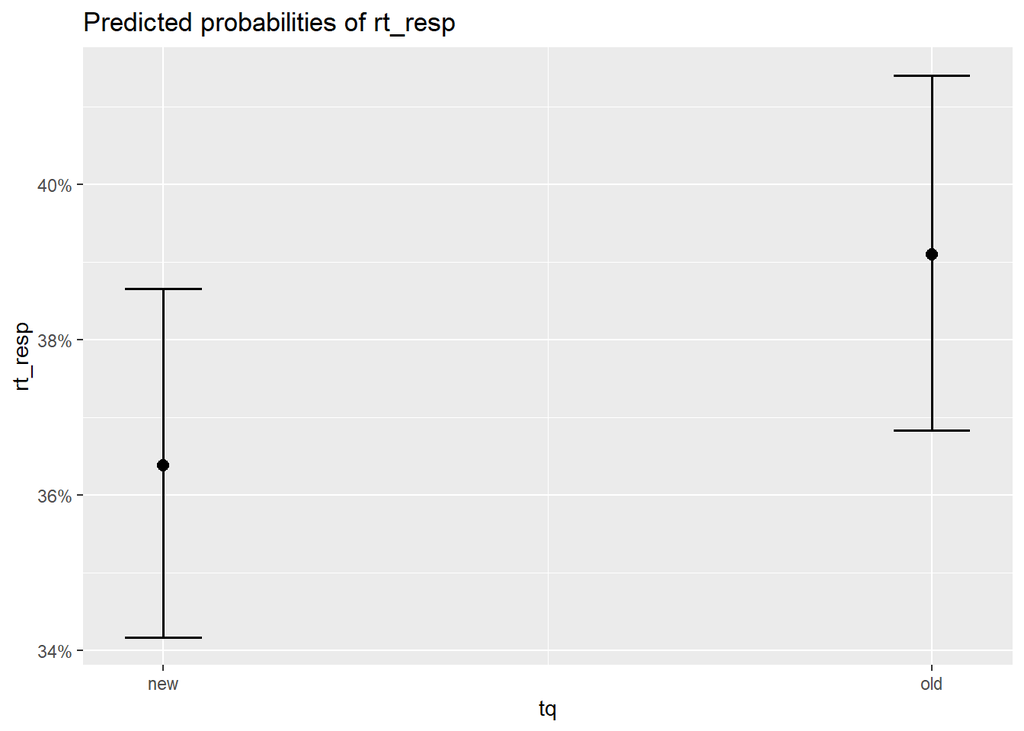

```
## Data were 'prettified'. Consider using `terms="DTAN [all]"` to get smooth plots.
```

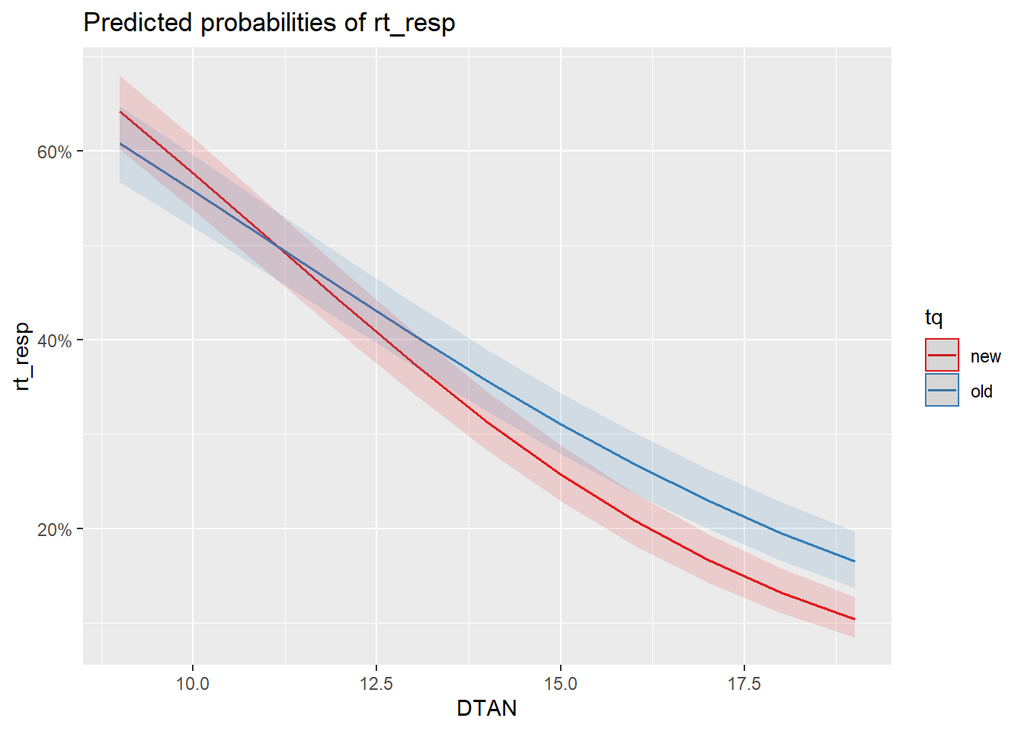

|  | rt_resp |  |  |  | rt_resp |  |  |  | rt_resp |  |  |  |
| --- | --- | --- | --- | --- | --- | --- | --- | --- | --- | --- | --- | --- |
| Predictors | Log-Odds | std. Error | CI | p | Log-Odds | std. Error | CI | p | Log-Odds | std. Error | CI | p |
| (Intercept) | 0.37 | 0.08 | 0.21 – 0.52 | **<0.001** | 2.19 | 0.14 | 1.91 – 2.47 | **<0.001** | 3.05 | 0.19 | 2.67 – 3.42 | **<0.001** |
| DTF | -0.12 | 0.01 | -0.13 – -0.11 | **<0.001** |  |  |  |  |  |  |  |  |
| tq [old] | -0.20 | 0.06 | -0.32 – -0.09 | **0.001** | -0.64 | 0.17 | -0.99 – -0.30 | **<0.001** | -0.75 | 0.25 | -1.24 – -0.27 | **0.002** |
| stid [orig] | -0.16 | 0.09 | -0.35 – 0.02 | 0.079 | -0.17 | 0.09 | -0.35 – 0.02 | 0.075 | -0.17 | 0.09 | -0.35 – 0.01 | 0.070 |
| DTF * tq [old] | 0.05 | 0.01 | 0.03 – 0.06 | **<0.001** |  |  |  |  |  |  |  |  |
| DTAF |  |  |  |  | -0.20 | 0.01 | -0.22 – -0.18 | **<0.001** |  |  |  |  |
| DTAF * tq [old] |  |  |  |  | 0.06 | 0.01 | 0.03 – 0.08 | **<0.001** |  |  |  |  |
| DTAN |  |  |  |  |  |  |  |  | -0.27 | 0.01 | -0.30 – -0.25 | **<0.001** |
| DTAN * tq [old] |  |  |  |  |  |  |  |  | 0.07 | 0.02 | 0.03 – 0.11 | **0.001** |
| Random Effects |  |  |  |  |  |  |  |  |  |  |  |  |
| σ<sup>2</sup> | 3.29 |  |  |  | 3.29 |  |  |  | 3.29 |  |  |  |
| τ<sub>00</sub> | 0.35 <sub>workerId</sub> |  |  |  | 0.34 <sub>workerId</sub> |  |  |  | 0.34 <sub>workerId</sub> |  |  |  |
| ICC | 0.09 |  |  |  | 0.09 |  |  |  | 0.09 |  |  |  |
| N | 189 <sub>workerId</sub> |  |  |  | 189 <sub>workerId</sub> |  |  |  | 189 <sub>workerId</sub> |  |  |  |
| Observations | 15476 |  |  |  | 15476 |  |  |  | 15476 |  |  |  |
| Marginal R<sup>2</sup> / Conditional R<sup>2</sup> | 0.079 / 0.167 |  |  |  | 0.074 / 0.161 |  |  |  | 0.059 / 0.147 |  |  |  |
| AIC | 19231.531 |  |  |  | 19256.026 |  |  |  | 19379.455 |  |  |  |
| AICc | 19231.537 |  |  |  | 19256.031 |  |  |  | 19379.461 |  |  |  |